## Primera minería de datos

En esta sección, realizamos una minería de datos a priori, con el objetivo de encontrar reglas de asociación. Sin embargo, nos encontramos con un problema, ya que el dataset estaba bastante desbalanceado y había muchas clases. Por ello, tras este apartado decidimos realizar una transformación (que en principio creimos que no era necesaria) para poder trabajar con un dataset más equilibrado.

### Asociación

```r
library(arules)
library(caret)
```

```r
library(FSelector)
library(arulesViz)
library(dplyr)
```

### Lectura de datos

```r
# Lectura de dataset
df=read.table("data/student-por.csv",sep=",",header=TRUE)

cols_to_factor <- c("school", "sex", "address", "famsize", "Pstatus", "Medu", "Fedu", "Mjob",
                    "Fjob", "reason", "guardian", "traveltime", "studytime" ,"famrel"
                    , "freetime", "goout", "health")

df[cols_to_factor] <- lapply(df[cols_to_factor], as.factor)

cols_to_boolean <- c("schoolsup", "famsup", "paid", "activities", "nursery", "higher", "internet", "romantic")

df[cols_to_boolean] <- lapply(df[cols_to_boolean], function(x) x == "yes")
```

```r
# Descartar la columna 'Dalc' del dataset para Hwalc, y descartar la columna 'Hwalc' del dataset para Hdalc
df_association <- df %>%
  mutate(Dalc = as.factor(Dalc),
         Walc = as.factor(Walc))
df_asociation_walc <- df_association[, -which(names(df_association) == "Dalc")]
df_asociation_dalc <- df_association[, -which(names(df_association) == "Walc")]
```

```r
# Ejecutar el algoritmo Apriori
rules <- apriori(df_asociation_dalc,
                 parameter = list(supp = 0.05, conf = 0.8, maxlen = 3),
                 appearance = list(rhs = paste("Dalc=", c("1","2","3", "4", "5"), sep="")))
```

```
## Apriori
##
## Parameter specification:
##  confidence minval smax arem  aval originalSupport maxtime support minlen
##         0.8    0.1    1 none FALSE            TRUE       5    0.05      1
##  maxlen target  ext
##       3  rules TRUE
##
## Algorithmic control:
##  filter tree heap memopt load sort verbose
##     0.1 TRUE TRUE  FALSE TRUE    2    TRUE
##
## Absolute minimum support count: 32
##
## set item appearances ...[5 item(s)] done [0.00s].
## set transactions ...[93 item(s), 649 transaction(s)] done [0.00s].
## sorting and recoding items ... [85 item(s)] done [0.00s].
## creating transaction tree ... done [0.00s].
## checking subsets of size 1 2 3
```

```
##  done [0.00s].
## writing ... [216 rule(s)] done [0.00s].
## creating S4 object  ... done [0.00s].
```

```r
inspect(head(rules))
```

```
##     lhs                     rhs      support    confidence coverage   lift
## [1] {goout=1}            => {Dalc=1} 0.06471495 0.8750000  0.07395994 1.259146
## [2] {Mjob=health}        => {Dalc=1} 0.06009245 0.8125000  0.07395994 1.169207
## [3] {G2=[13,19]}         => {Dalc=1} 0.28659476 0.8017241  0.35747304 1.153701
## [4] {G3=[13,19]}         => {Dalc=1} 0.34206471 0.8043478  0.42526965 1.157476
## [5] {nursery, goout=1}   => {Dalc=1} 0.05546995 0.8780488  0.06317411 1.263534
## [6] {Pstatus=T, goout=1} => {Dalc=1} 0.05546995 0.8571429  0.06471495 1.233449
##     count
## [1]  42
## [2]  39
## [3] 186
## [4] 222
## [5]  36
## [6]  36
```

```r
rules_lift <- subset(rules, lift > 1.2)

rules_sorted <- sort(rules_lift, by = "confidence", decreasing = TRUE)

inspect(head(rules_sorted, 10))
```

```
##      lhs                           rhs      support    confidence coverage
## [1]  {health=3, G3=[13,19]}     => {Dalc=1} 0.06933744 0.9000000  0.07704160
## [2]  {sex=F, health=3}          => {Dalc=1} 0.10323575 0.8933333  0.11556240
## [3]  {sex=F, famrel=5}          => {Dalc=1} 0.13097072 0.8854167  0.14791988
## [4]  {famrel=5, freetime=3}     => {Dalc=1} 0.09399076 0.8840580  0.10631741
## [5]  {sex=F, Medu=2}            => {Dalc=1} 0.16178737 0.8823529  0.18335901
## [6]  {health=3, G1=[13,19]}     => {Dalc=1} 0.05701079 0.8809524  0.06471495
## [7]  {nursery, goout=1}         => {Dalc=1} 0.05546995 0.8780488  0.06317411
## [8]  {goout=2, absences=[4,32]} => {Dalc=1} 0.07704160 0.8771930  0.08782743
## [9]  {goout=1}                  => {Dalc=1} 0.06471495 0.8750000  0.07395994
## [10] {higher, goout=1}          => {Dalc=1} 0.05392912 0.8750000  0.06163328
##      lift     count
## [1]  1.295122  45
## [2]  1.285528  67
## [3]  1.274136  85
## [4]  1.272181  61
## [5]  1.269727 105
## [6]  1.267712  37
## [7]  1.263534  36
## [8]  1.262302  50
## [9]  1.259146  42
## [10] 1.259146  35
```

```
## To reduce overplotting, jitter is added! Use jitter = 0 to prevent jitter.
```

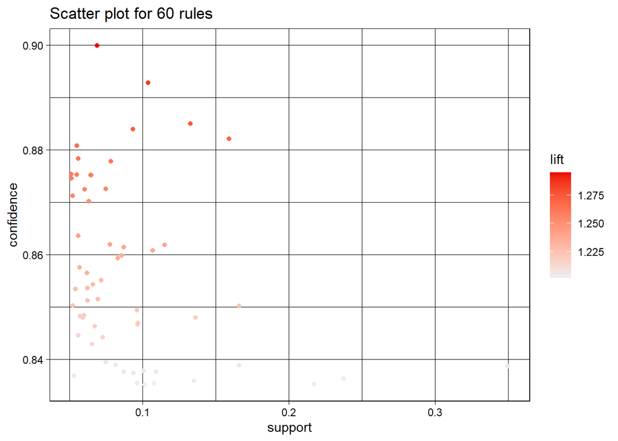

```r
# Visualización básica
plot(rules_sorted)
```

```r
# Gráfico interactivo
plot(rules_sorted, method = "graph", engine = "htmlwidget")
```

[interactive chart not shown]

En este caso, vamos a buscar reglas de asociación para el consumo de alcohol entre semana para valores 3, 4 y 5. Esto debido a que como se observó anteriormente, con un soporte y confianza mayores solo se obtienen reglas relacionadas con consumo bajo de alcohol, lo cual no ayuda a tener referencia de todas las clases.

```r
# Ejecutar el algoritmo Apriori

rules <- apriori(df_asociation_dalc,
                 parameter = list(supp = 0.001, conf = 0.6, maxlen = 3),
                 appearance = list(rhs = paste("Dalc=", c( "3", "4", "5"), sep="")))
```

```
## Apriori
##
## Parameter specification:
##  confidence minval smax arem  aval originalSupport maxtime support minlen
##         0.6    0.1    1 none FALSE            TRUE       5   0.001      1
##  maxlen target  ext
##       3  rules TRUE
##
## Algorithmic control:
##  filter tree heap memopt load sort verbose
##     0.1 TRUE TRUE  FALSE TRUE    2    TRUE
##
## Absolute minimum support count: 0
##
## set item appearances ...[3 item(s)] done [0.00s].
## set transactions ...[93 item(s), 649 transaction(s)] done [0.00s].
## sorting and recoding items ... [93 item(s)] done [0.00s].
## creating transaction tree ... done [0.00s].
## checking subsets of size 1 2 3
```

```
##  done [0.00s].
## writing ... [22 rule(s)] done [0.00s].
## creating S4 object  ... done [0.00s].
```

```r
inspect(head(rules))
```

```
##     lhs                          rhs      support     confidence coverage
## [1] {Medu=0, famrel=2}        => {Dalc=3} 0.001540832 1          0.001540832
## [2] {Medu=0, goout=4}         => {Dalc=3} 0.001540832 1          0.001540832
## [3] {Medu=0, G2=[0,10)}       => {Dalc=3} 0.001540832 1          0.001540832
## [4] {Medu=0, G3=[0,11)}       => {Dalc=3} 0.001540832 1          0.001540832
## [5] {Medu=0, absences=[4,32]} => {Dalc=3} 0.001540832 1          0.001540832
## [6] {traveltime=4, famrel=1}  => {Dalc=3} 0.001540832 1          0.001540832
##     lift     count
## [1] 15.09302 1
## [2] 15.09302 1
## [3] 15.09302 1
## [4] 15.09302 1
## [5] 15.09302 1
## [6] 15.09302 1
```

```r
rules_lift <- subset(rules, lift > 1.2)

rules_sorted <- sort(rules_lift, by = "confidence", decreasing = TRUE)

inspect(head(rules_sorted, 10))
```

```
##      lhs                               rhs      support     confidence
## [1]  {Medu=0, famrel=2}             => {Dalc=3} 0.001540832 1
## [2]  {Medu=0, goout=4}              => {Dalc=3} 0.001540832 1
## [3]  {Medu=0, G2=[0,10)}            => {Dalc=3} 0.001540832 1
## [4]  {Medu=0, G3=[0,11)}            => {Dalc=3} 0.001540832 1
## [5]  {Medu=0, absences=[4,32]}      => {Dalc=3} 0.001540832 1
## [6]  {traveltime=4, famrel=1}       => {Dalc=3} 0.001540832 1
## [7]  {Medu=4, traveltime=4}         => {Dalc=3} 0.001540832 1
## [8]  {Fjob=teacher, traveltime=3}   => {Dalc=4} 0.001540832 1
## [9]  {guardian=other, freetime=1}   => {Dalc=4} 0.001540832 1
## [10] {reason=other, guardian=other} => {Dalc=4} 0.001540832 1
##      coverage    lift     count
## [1]  0.001540832 15.09302 1
## [2]  0.001540832 15.09302 1
## [3]  0.001540832 15.09302 1
## [4]  0.001540832 15.09302 1
## [5]  0.001540832 15.09302 1
## [6]  0.001540832 15.09302 1
## [7]  0.001540832 15.09302 1
## [8]  0.001540832 38.17647 1
## [9]  0.001540832 38.17647 1
## [10] 0.001540832 38.17647 1
```

```
## To reduce overplotting, jitter is added! Use jitter = 0 to prevent jitter.
```

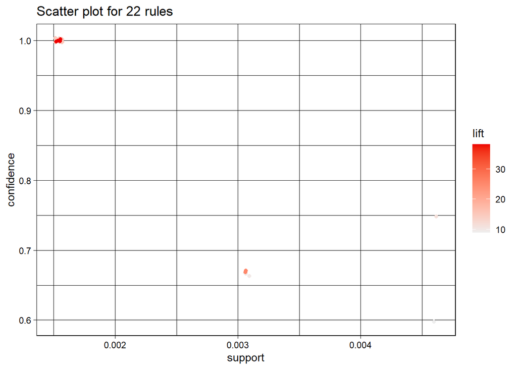

```r
# Visualización básica
plot(rules_sorted)
```

```r
# Gráfico interactivo
plot(rules_sorted, method = "graph", engine = "htmlwidget")
```

[interactive chart not shown]